# FigureYa117multilinearDE

# Academic Citation

If you use this code in your work or research, we kindly request that you cite our publication:

Xiaofan Lu, et al. (2025). FigureYa: A Standardized Visualization Framework for Enhancing Biomedical Data Interpretation and Research Efficiency. iMetaMed. https://doi.org/10.1002/imm3.70005

## 需求描述

去除RNAseq表达量混杂因素，混杂因素包括年龄、性别、人种、批次等。 方法在文章method部分的Differential expression analyses里面描述。 结果图可以放两个热图进行比较

## Requirement description

Remove confounding factors such as age, gender, race, batch, etc. that affect RNAseq expression levels. The method is described in the differential expression analyses section of the article. The result chart can be compared with two heat maps

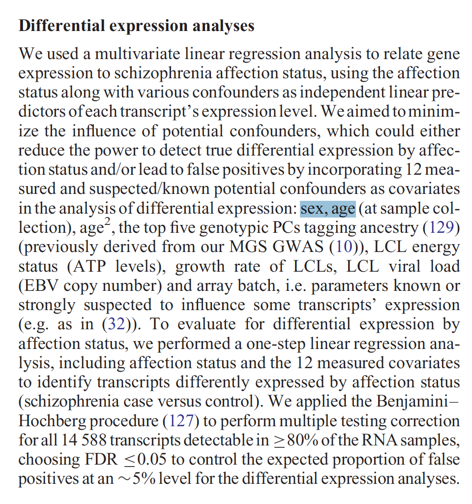

出自https://academic.oup.com/hmg/article/22/24/5001/568201

fromhttps://academic.oup.com/hmg/article/22/24/5001/568201

或参考：Evaluation of logistic regression models and effect of covariates for case–control study in RNA-Seq analysis，https://link.springer.com/article/10.1186%2Fs12859-017-1498-y

Or reference: Evaluation of logistic regression models and effect of covariates for case–control study in RNA-Seq analysis，< https://link.springer.com/article/10.1186%2Fs12859 -017-1498-y>

## 应用场景

用于做差异表达分析。大规模测序数据，往往混杂着各种协变量，影响差异基因筛选，常见的两种策略：

- 策略一，去除这些混杂因素，例文采取的是这种策略；
- 策略二，把这些因素加入到DESeq2的design里，推荐这种策略。

下面这篇文章详细探讨了第一种方式的缺点，并给出了实际操作时的指导意见：2016年的Biostatistics，Methods that remove batch effects while retaining group differences may lead to exaggerated confidence in downstream analyses，https://t.zsxq.com/3j2beI6

## Application scenarios

Used for differential expression analysis. Large scale sequencing data is often mixed with various covariates, which affect differential gene screening. There are two common strategies:

-Strategy one is to remove these confounding factors, which is adopted in the example text; -Strategy 2: Incorporate these factors into the design of DESeq2 and recommend this strategy.

The following article discusses in detail the drawbacks of the first approach and provides guidance for practical operation: 2016 Biostatistics，Methods that remove batch effects while retaining group differences may lead to exaggerated confidence in downstream analyses，< https://t.zsxq.com/3j2beI6 >

## Environment settings

Use domestic image installation package

```r
source("install_dependencies.R")
```

```
## Starting R package installation...
## ===========================================
##
## Installing CRAN packages...
## Package already installed: ClassDiscovery
## Package already installed: glmnet
## Package already installed: gplots
## Package already installed: pheatmap
##
## ===========================================
## Package installation completed!
## You can now run your R scripts in this directory.
```

```r
# 加载glmnet包，用于正则化线性模型，如LASSO和弹性网络（Load the glmnet package for regularized linear models such as LASSO and Elastic-Net）
library(glmnet)
```

```r
# 加载pheatmap包，用于创建美观的热图（Load the pheatmap package for creating beautiful heatmaps）
library(pheatmap)
# 加载ClassDiscovery包，用于基因表达数据的聚类和分类（Load the ClassDiscovery package for clustering and classification of gene expression data）
library(ClassDiscovery)
# 加载gplots包，提供额外的绘图功能（Load the gplots package for additional plotting functions）
library(gplots)
# 设置环境语言为英语，使报错信息以英文显示（Set the environment language to English to display error messages in English）
Sys.setenv(LANGUAGE = "en")

# 禁止字符串自动转换为因子类型，避免数据处理中的意外转换（Prevent automatic conversion of strings to factors to avoid unexpected data type changes）
options(stringsAsFactors = FALSE)
```

自定义函数

Custom functions

```r
# 显示差异表达分析进度（Display progress of differential expression analysis）
# index: 当前处理的索引（Current processing index）
# totalN: 总处理数量（Total number of items to process）
# breakN: 进度显示的分割数（Number of progress updates to display）
display.progress = function ( index, totalN, breakN=20) {

  # 每处理一定数量的项目时显示进度百分比（Display progress percentage at regular intervals）
  if ( index %% ceiling(totalN/breakN)  ==0  ) {
    cat(paste(round(index*100/totalN), "% ", sep=""))
  }
}

# 多变量线性回归差异表达分析（考虑其他协变量）（Multivariable linear regression for differential expression analysis considering covariates）
# emat: 输入的表达矩阵（行为基因；列为样本），一般是适用于回归模型的数据变量，如FPKM，TPM，标准化的count以及芯片数据等（Input expression matrix with genes as rows and samples as columns）
# sinfo: 样本信息，包括差异表达的两个组，其他感兴趣变量或批次效应（协变量）（Sample information including groups for comparison and covariates）
# res.var: response variable逻辑回归中的响应变量（单一字符串），及差异表达要比较的两个组，请优先转换为1和0（Response variable for logistic regression, should be binary (1/0)）
# cov.var: covariate variable逻辑回归中的协变量（可为多个变量），及差异表达时要考虑的其他因素，请优先添加额外的因素，比如age的平方等（Covariate variables to adjust for in the model）
# logtrans: 逻辑变量，指示在逻辑回归时对基因表达量是否做log2转化，默认为TRUE（Whether to log2 transform gene expression values, default is TRUE）
# isorder: 逻辑变量，指示是否对结果中的FDR进行升序排列，默认为TRUE（Whether to sort results by FDR, default is TRUE）
multilinearDE <- function(emat = NULL, sinfo = NULL, res.var = NULL, cov.var = NULL, logtrans = T, isorder = T) {

  # 验证表达矩阵和样本信息的样本ID是否匹配（Validate sample IDs match between expression matrix and sample information）
  if(!identical(colnames(emat),rownames(sinfo))) {
    stop("Error! The sampleIDs are not matched in emat and sinfo!\n")
  }

  # 确保响应变量为0和1且二者均存在（Ensure response variable is binary with both 0 and 1 present）
  if(sum(is.element(c("1","0"),as.character(sinfo[,res.var]))) != 2) {
    stop("Error! The response variable must be 1 and 0, please transform it first!\n")
  }

  # 验证所有变量都存在于样本信息中（Validate all variables exist in sample information）
  if(!all(is.element(c(res.var,cov.var),colnames(sinfo)))) {
    stop("Error! All the variable should be included in sinfo with the same label name!\n")
  }

  # 初始化结果变量（Initialize result variables）
  p.gene <- fc <- log2fc <- c()
  for (i in 1:nrow(emat)) {

    # 显示计算进度（Display progress）
    display.progress(index = i,totalN = nrow(emat))

    gene = rownames(emat)[i]

    # 根据logtrans参数决定是否对表达值进行log2转换（Log transform expression values if specified）
    if(logtrans) {
      tmp <- cbind.data.frame(gene = log2(t(emat[gene,]) + 1), sinfo)
    } else { tmp <- cbind.data.frame(gene = t(emat[gene,]), sinfo) }
    colnames(tmp)[1] <- "gene"

    # 构建逻辑回归公式（Construct logistic regression formula）
    f <-  as.formula(paste(res.var, "~", paste(c("gene",cov.var), collapse = ' + ')))

    # 执行二元多变量逻辑回归（Perform binomial logistic regression）
    model_glm <- glm(f, data = tmp, family = "binomial")
    # 提取基因表达的p值（Extract p-value for gene expression）
    p.gene <- c(p.gene,summary(model_glm)$coefficients["gene",4])

    # 计算两组样本的表达均值比（Calculate fold change between groups）
    a <- as.numeric(emat[gene,which(tmp$class == "1"),])
    b <- as.numeric(emat[gene,which(tmp$class == "0"),])
    fc <- c(fc,mean(a)/mean(b))
    log2fc <- c(log2fc,log2(mean(a)/mean(b)))
  }

  # 生成差异表达结果表格（Generate differential expression results table）
  outTab <- data.frame(gene = rownames(emat),
                       fc = fc,
                       log2fc = log2fc,
                       p.value = p.gene,
                       fdr = p.adjust(p.gene,method = "fdr"),
                       stringsAsFactors = F)

  # 根据isorder参数决定是否按FDR排序结果（Sort results by FDR if specified）
  if(isorder) {
    outTab <- outTab[order(outTab$fdr),]
    return(outTab)
  } else {return(outTab)}
}
```

## 输入文件

easy_input_expr.txt，表达矩阵。

easy_input_info.txt，样品信息，包含亚型、年龄、性别。

## Input file

easy_input_expr.txt， Expression matrix.

easy_input_info.txt， Sample information, including subtype, age, and gender.

```r
# 读取表达谱数据（Read gene expression matrix）
# 文件格式：制表符分隔，第一行为列名，第一列为行名（基因名）（Tab-separated format with header and gene names as row names）
expr <- read.table("easy_input_expr.txt",sep = "\t",check.names = F,stringsAsFactors = F,row.names = 1,header = T)
# 查看数据前几行和列（Preview the first few rows and columns）
expr[1:3, 1:3]
```

```
##         SKCM-A1PV-01A SKCM-A1Q0-01A SKCM-A1Q1-06A
## TNMD             0.00          0.01          0.17
## PDK4             0.14          0.30          1.72
## SLC25A5        123.34        103.22         84.68
```

```r
# 读取样本信息数据（Read sample information）
# 文件格式：制表符分隔，第一行为列名，第一列为样本ID（Tab-separated format with header and sample IDs as row names）
sinfo <- read.table("easy_input_info.txt",sep = "\t",check.names = F,stringsAsFactors = F,row.names = 1,header = T)
# 查看样本信息的基本结构（Preview sample information structure）
head(sinfo)
```

```
##               TCGA Subtype age    sex
## SKCM-A1PU-01A      keratin  NA   <NA>
## SKCM-A1PV-01A      keratin  74 FEMALE
## SKCM-A1PX-01A      keratin  NA   <NA>
## SKCM-A1PZ-01A      keratin  NA   <NA>
## SKCM-A1Q0-01A       immune  80   MALE
## SKCM-A3DJ-01A      keratin  NA   <NA>
```

```r
# 匹配表达矩阵和样本信息中的样本ID（Match samples between expression matrix and sample information）
# 仅保留两者共有的样本，并移除存在协变量缺失值的样本（Keep only overlapping samples and remove those with missing covariates）
sinfo <- as.data.frame(na.omit(sinfo[intersect(rownames(sinfo),colnames(expr)),]))
sinfo <- as.data.frame(na.omit(sinfo))

# 创建二分类变量class，用于差异表达分析（Create binary classification variable for differential expression analysis）
# 将TCGA Subtype为immune的样本设为1，其他设为0（Set immune subtype samples to 1, others to 0）
sinfo$class <- ifelse(sinfo$`TCGA Subtype` == "immune",1,0)

# 准备用于差异表达分析的表达矩阵（Prepare expression matrix for differential expression analysis）
# 仅保留有完整样本信息的样本对应的表达数据（Keep only samples with complete information）
emat <- expr[,rownames(sinfo)]
```

## 多变量逻辑回归确定显著转录本

## Multivariate logistic regression to determine significant transcripts

```r
# 创建年龄的二次项作为额外协变量（Create age squared as an additional covariate）
# 用于捕捉年龄与基因表达之间的非线性关系（To capture potential nonlinear effects of age）
sinfo$age2 <- sinfo$age^2

# 执行多变量线性回归差异表达分析（Perform multivariable linear regression for differential expression analysis）
# 考虑年龄、年龄平方和性别作为协变量（Adjust for age, age squared, and gender as covariates）
outTab <- multilinearDE(emat = emat,
                        sinfo = sinfo,
                        res.var = "class",        # 响应变量：免疫亚型 vs 其他亚型（Response variable: immune subtype vs others）
                        cov.var = c("age","age2","sex"),  # 协变量：年龄、年龄平方和性别（Covariates: age, age squared, and gender）
                        logtrans = T,             # 对表达值进行log2转换（Log-transform expression values）
                        isorder = F)              # 不按FDR排序结果（Do not sort results by FDR）
```

```
## 5%
```

```
## 10%
```

```
## 15%
```

```
## 20%
```

```
## 25%
```

```
## 30%
```

```
## 35%
```

```
## 40%
```

```
## 45%
```

```
## 50%
```

```
## 55%
```

```
## 60%
```

```
## 65%
```

```
## 70%
```

```
## 75%
```

```
## 80%
```

```
## 85%
```

```
## 90%
```

```
## 95%
```

```r
# 查看结果前几行（Preview the first few results）
head(outTab)
```

```
##      gene          fc     log2fc      p.value          fdr
## 1    TNMD 0.276217270 -1.8561246 1.984839e-01 4.299581e-01
## 2    PDK4 1.158967983  0.2128407 9.345753e-02 2.858144e-01
## 3 SLC25A5 0.866446175 -0.2068180 4.176226e-02 1.763484e-01
## 4  HOXA11 0.487677672 -1.0360002 5.121290e-10 3.599920e-08
## 5    SOX8 0.876632489 -0.1899559 4.825488e-01 6.878201e-01
## 6  KRT33A 0.004841564 -7.6903111 4.573959e-02 1.867535e-01
```

```r
# 将差异表达分析结果输出到文件（Export differential expression results to a text file）
# 文件格式：制表符分隔，不含行名，不使用引号（Tab-separated format without row names or quotes）
write.table(outTab,
            "DE results by multilinear regression considering covariates.txt",
            sep = "\t",
            row.names = F,
            quote = F)
```

## 开始画图

通过绘制热图查看分型效果

## Start drawing

View the typing effect by drawing a heat map

```r
# 筛选差异表达基因（Select differentially expressed genes）
# 筛选标准：FDR < 0.05 且 绝对log2FC > 2（Criteria: FDR < 0.05 and absolute log2 fold change > 2）
degs <- outTab[which(outTab$fdr < 0.05 & abs(outTab$log2fc) > 2), "gene"]

# 创建样本注释信息（Create sample annotation for heatmap）
# 基于class变量标记样本类型（Label samples by class variable）
annCol <- data.frame(class=sinfo$class,row.names = rownames(sinfo),stringsAsFactors = F)
annCol$class <- ifelse(annCol$class == 1,"Immune","Others")

# 为热图注释设置颜色（Set colors for heatmap annotations）
# Immune组使用蓝色，Others组使用黄色（Blue for Immune group, yellow for Others）
annColors <- list("class"=c("Immune"="#2874C5","Others"="#EABF00"))

# 对表达矩阵进行log2转换（Log2 transform expression matrix）
indata <- log2(emat + 1)

# 计算样本间的层次聚类（Hierarchical clustering for samples）
# 使用欧氏距离和ward.D方法（Euclidean distance with ward.D linkage）
hcg <- hclust(distanceMatrix(as.matrix(t(indata[degs,rownames(sinfo)])), "euclidean"), "ward.D")

# 计算基因间的层次聚类（Hierarchical clustering for genes）
# 使用欧氏距离和ward.D方法（Euclidean distance with ward.D linkage）
hcs <- hclust(distanceMatrix(as.matrix(indata[degs,rownames(sinfo)]), "euclidean"), "ward.D")

# 数据标准化并截断异常值（Standardize data and truncate extreme values）
# 将表达值标准化后限制在[-3,3]区间（Standardize and limit values to [-3, 3]）
plotdata <- t(scale(t(indata)))
plotdata[plotdata >= 3] <- 3
plotdata[plotdata <= -3] <- -3

# 绘制差异表达基因的热图（Plot heatmap of differentially expressed genes）
# 使用pheatmap包创建带样本注释的热图（Create annotated heatmap with pheatmap）
pheatmap(plotdata[degs,],
         annotation_col = annCol,          # 添加样本注释（Add sample annotations）
         annotation_colors = annColors,    # 设置注释颜色（Set annotation colors）
         cluster_cols = hcs,               # 使用预计算的列聚类（Use precomputed column clustering）
         show_rownames = F,                # 不显示行名（Hide gene names）
         show_colnames = F,                # 不显示列名（Hide sample names）
         cluster_rows = hcg,               # 使用预计算的行聚类（Use precomputed row clustering）
         labels_col = NULL,                # 不显示列标签（No column labels）
         labels_row = NULL,                # 不显示行标签（No row labels）
         filename = "heatmap for DEGs.pdf") # 保存为PDF文件（Save as PDF）
```

[figure not shown]

从热图可以看出差异表达基因较好地分开了immune 和 others亚型，去除混杂因素的效果还不错。

From the heatmap, it can be seen that the differentially expressed genes have effectively separated the immune and other subtypes, and the effect of removing confounding factors is also good.